# Projekt 2 Faza 1

Patrycja Matys, Jan Rosa, Krzysztof Rutkowski, Magda Sobiczewska

17 maja 2016

## Wprowadzenie

Dokonaliśmy eksploracji danych zawierających liczbę przypadków raka piersi w Polsce w latach 2010, 2011, 2012 z podziałem na płeć, 6 kategorii wiekowych, kod TERYT/powiat, województwo oraz fazę choroby. Wykorzystaliśmy również dane z GUS, aby pracować jedynie na znormalizowanych danych oraz bazy współrzędnych geograficznych z https://github.com/pbiecek/teryt, by wykonać kartogramy.

Dokonując synchronizacji wyjściowych danych z danymi GUS napotkaliśmy dwie rozbieżności. W GUS brak informacji na temat powiatu o kodzie TERYT 1431, stąd pominęliśmy ten powiat w eksploracji oraz w danych wyjściowych brakuje kodu TERYT 0265 (miasto Wałbrzych), który występuje w GUS - zdecydowaliśmy, że utożsamimy TERYT 0265 (miasto Wałbrzych) z TERYT 0221 (powiat wałbrzyski).

Na wstępie szukaliśmy poziomów danych interesujących statystycznie i w dalszej części raportu będziemy pracować tylko na tych najbardziej interesujących.

## Hipoteza badawcza

Naszym głównym celem była szeroka eksploracja danych i znalezienie czynników, które wpływają na rozmieszczenie raka piersi w całej Polsce.

## Analiza czynników wpływających na liczbę zachorowań

### Płeć

Na początku chcieliśmy zobaczyć, jak wyglądają znormalizowane dane w zależności od płci (liczbę zachorowań w danym województwie podzieliliśmy przez ludność województwa).

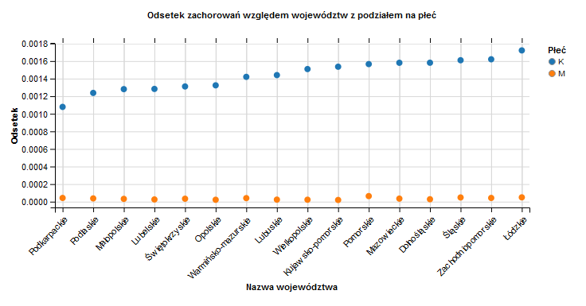

Z powyższego wykresu widzimym, że odsetki dla mężczyzn w podziale na województwa są niewielkie i równomiernie rozłożone - czego też mogliśmy się spodziewać patrząc na typ raka. Na postawie tego wyniku uznaliśmy, że informacje o zachorowaniach płci męskiej są drugorzędne, zatem dalej będziemy rozważać jedynie populację kobiet (w dalszej części raportu pracujemy na następującej normalizacji danych: liczbę zachorowań kobiet podzieliliśmy przez ludność kobiet w województwie lub powiecie).

### Grupa wiekowa

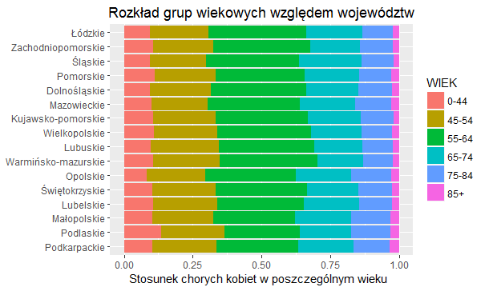

Na powyższym wykresie widzimy, że rozkład grup wiekowych w zależności od województwa jest zbliżony w obrębie całej Polski. Najwięcej kobiet choruje w średnim wieku - między 55, a 64 lat.

### Faza choroby

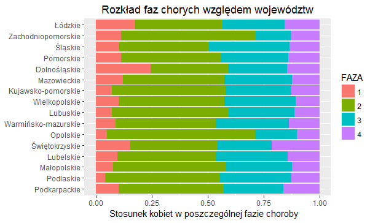

Na powyższym wykresie widzimy, że również rozkład różnych faz choroby w zależności od województwa jest zbliżony w obrębie całej Polski (chociaż wyróżniają się trzy województwa: w dolnośląskim widzimy większy procent zachorowań na fazę 1, a w zachodniopomorskim oraz opolskim na fazę 2). Najwięcej zachorowań wykrywa się w drugiej fazie choroby.

Pokazaliśmy, że rozkład grup wiekowych i faz nie jest istonie ważny ze względu na kryteria geograficzne, i jest zbliżony w obrębie całej Polski. Zatem dalej będziemy pracować na danych zsumowanych zarówno względem wieku i faz.

### Województwo

Na poniższym kartogramie widać wyraźny podział zachorowań ze względu na województwa, istnieje podział: Polska środkowa wraz z północnym zachodem versus południowy wschód. Największy odsetek zachorowań posiada województwo łódzkie oraz zachodnio-pomorskie, a najmniejszy podkarpackie.

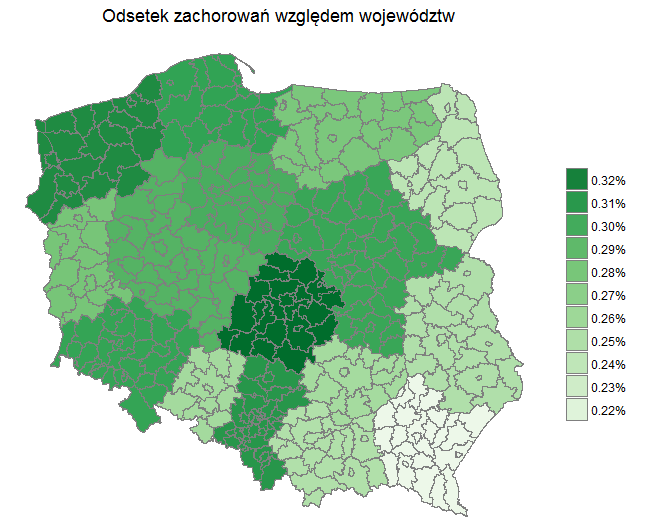

### Powiat

Z kolei gdy zobaczymy na kartogram dla powiatów, nie widzimy już tak wyraźnej różnicy jeśli chodzi o województwa. Jednak widać wyraźnie, że dominującymi powiatami są duże miasta i to one znacząco wpływają na województwo.

[figure not shown]

Spójrzmy teraz na 15 powiatów, w których odsetek zachorowań jest największy. Są wśród nich głównie duże miasta przemysłowe.

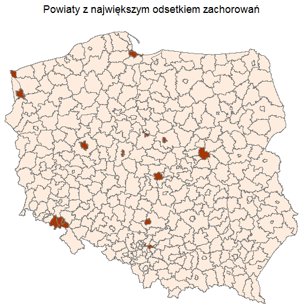

Są to następujące powiaty (w nawiasach wielkość odsetek zachorowań): Sopot (0.00574), Sosnowiec (0.00432), Łódź (0.00428), Częstochowa (0.00416), Świnoujście (0.00413), Konin (0.00410), Wałbrzyski (0.00401), Płock (0.00399), Poznań (0.00394), Warszawa (0.00390), Włocławek (0.00387), Siemianowice Śląskie (0.00386), kamiennogórski (0.00386), Gdańsk (0.00385), Szczecin (0.00385).

## Analiza rozkładu zachorowań powiatów względem województw

Z powyższych kartogramów widzimy, że dominujący wpływ na odsetek zachorowań w danym województwie mają duże miasta (głównie przemysłowe). Przyjrzeliśmy się jak wygląda rozkład odsetka zachorowań w powiatach w każdym województwie. I tu wyrózniliśmy dwie grupy - województwa nie posiadające dużego miasta przemysłowego - jak świętokrzyskie czy lubuskie, gdzie nie było wyraźnego dominatora, jak i województwa z wyraźnym dominatorem - miastem, które wybijało się ponad inne powiaty.

### Województwa bez większego miasta

W poniższych województwach mamy mały odsetek zachorowań, ale nie ma większego miasta, które wpływałoby na odsetek zachorowań. Największe odsetki zachorowań mają powiaty, które nie są miastami.

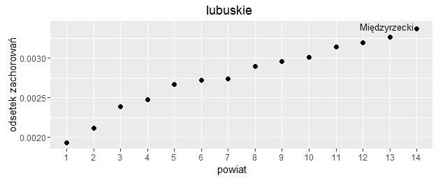

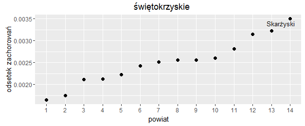

### Województwa z większym miastem

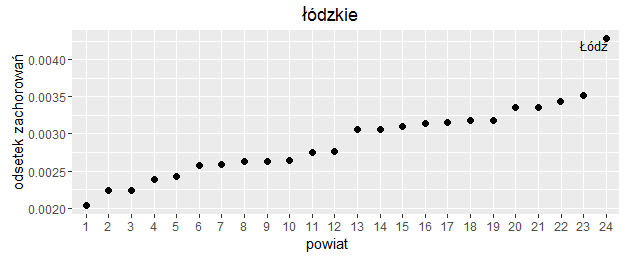

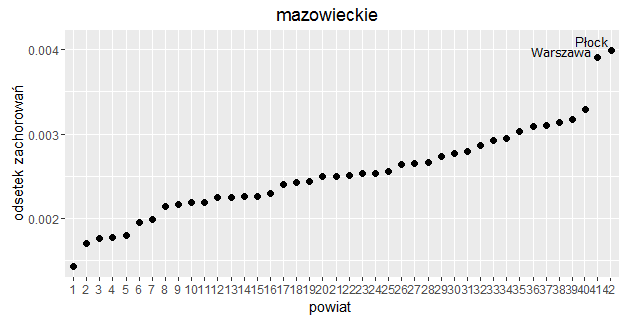

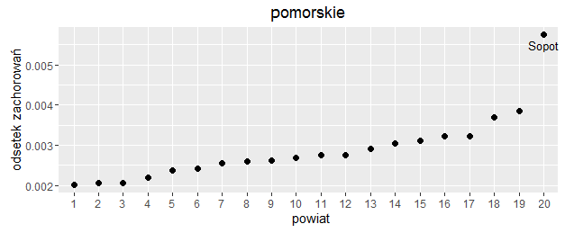

## Podsumowanie

Z poniższych analiz można wywnioskować, że ważnym czynnikiem wpływającym na liczbę zachorowań jest wiek, jednak ten czynnik nie jest uwarunkowany geograficznie. Dominującym czynnikiem geograficznym wpływającym na liczbę zachorowań jest podział duże miasto przemysłowe - inny powiat. Ten podział wydaje się dużo bardziej zasadny niż kryterium np. województwa.